# SOAK Census 2024

### Participation

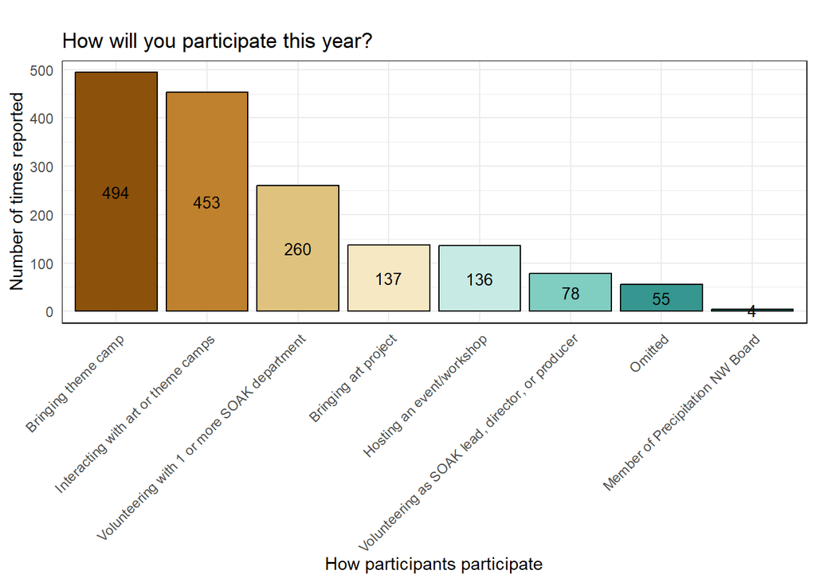

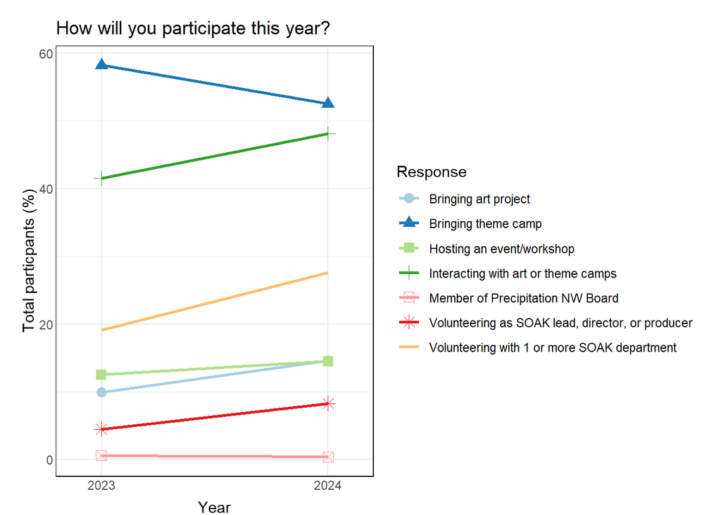

How will you participate this year?

| Response | 2023 Count | 2023 Percent | 2024 Count | 2024 Percent |
| --- | --- | --- | --- | --- |
| Bringing theme camp | 390 | 58.2 | 494 | 52.5 |
| Interacting with art or theme camps | 278 | 41.5 | 453 | 48.1 |
| Volunteering with 1 or more SOAK department | 128 | 19.1 | 260 | 27.6 |
| Bringing art project | 66 | 9.9 | 137 | 14.6 |
| Hosting an event/workshop | 84 | 12.5 | 136 | 14.5 |
| Volunteering as SOAK lead, director, or producer | 30 | 4.5 | 78 | 8.3 |
| Omitted | 30 | 4.5 | 55 | 5.8 |
| Member of Precipitation NW Board | 4 | 0.6 | 4 | 0.4 |

How did you participate at SOAK in 2024? Participants could select more than one option, therefore the percent here is out of participants and not responses (totaling above 100). Most people helped bring a theme camp! A total of 52.5% reported bringing a theme camp, which is a decrease from 2023. Second to bringing a camp, 48.1% of people reported interacting with art or theme camps, which increased from 2023.

The least common forms of participation were volunteering as a lead, director, producer, or board member. [Volunteerism in Black Rock City claimed 12.6% of Burners in 2023](https://blackrockcitycensus.org/regionals_media_volunteering#volunteered-in-the-last-year), but 27.6% of SOAKers volunteered with 1 or more SOAK department. This is an increase from 2023, where 19.1% of participants volunteered.

### Sustainability

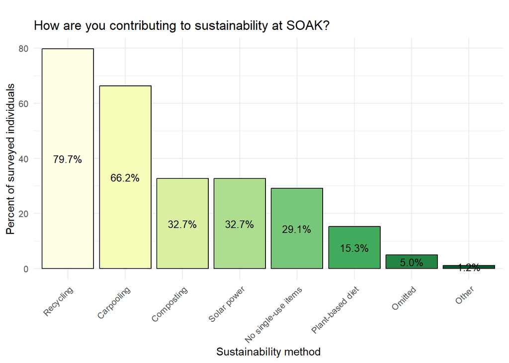

How are you contributing to sustainability?

| Sustainability | 2023 Count | 2023 Percent | 2024 Count | 2024 Percent |
| --- | --- | --- | --- | --- |
| Recycling | 536 | 80.0 | 750 | 79.7 |
| Carpooling | 429 | 64.0 | 623 | 66.2 |
| Composting | 218 | 32.5 | 308 | 32.7 |
| Solar power | 172 | 25.7 | 308 | 32.7 |
| No single-use items | 192 | 28.7 | 274 | 29.1 |
| Plant-based diet | 132 | 19.7 | 144 | 15.3 |
| Omitted | 20 | 3.0 | 47 | 5.0 |
| Other | 18 | 2.7 | 11 | 1.2 |

### Inclusion of Minors

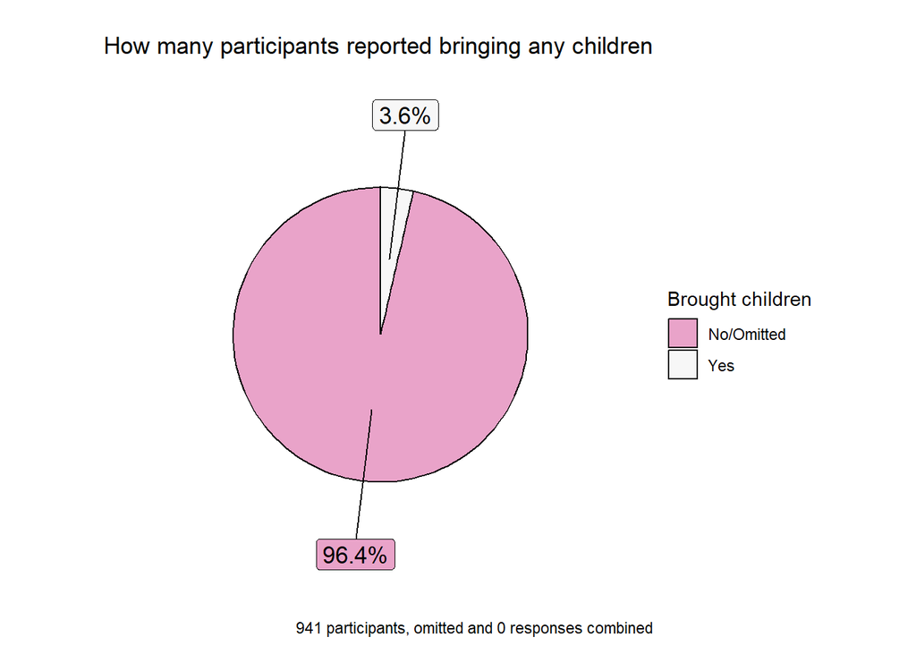

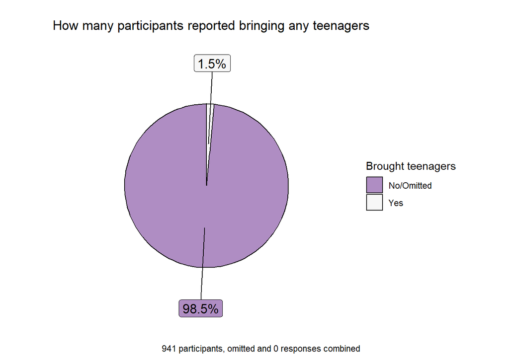

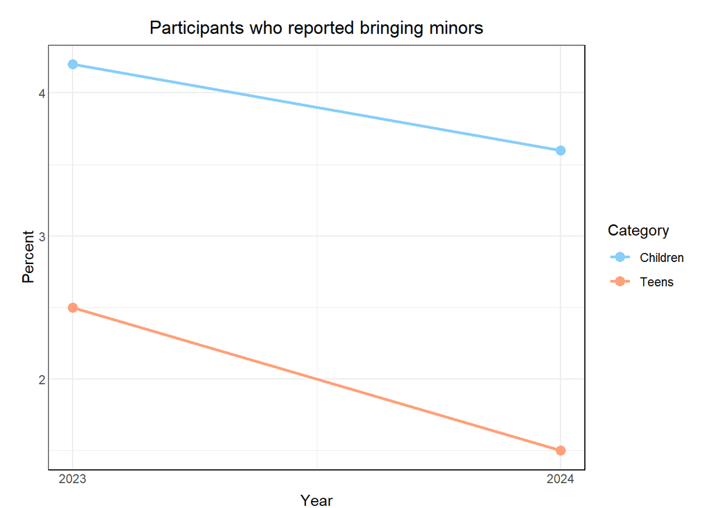

Most participants do not bring minors with them to SOAK. The number has decreased between 2023 and 2024.Compared to Burning Man in 2023, [2.8% of Burners reported ever bringing someone under 18 years of age](https://blackrockcitycensus.org/perspectives#bringing-children-under-18-years-old), SOAKers have a higher rate of brining minors.

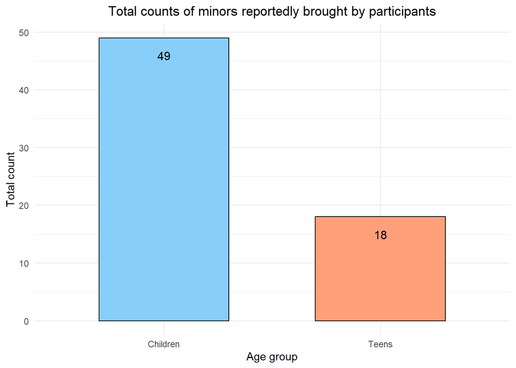

## Town Hall and Burning Man

### Town Hall

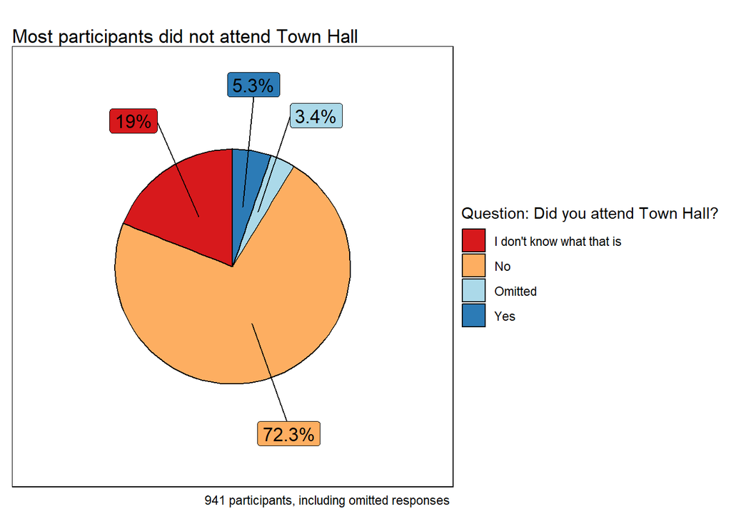

Did you attend Town Hall?

| Response | 2023 Count | 2023 Percent | 2024 Count | 2024 Percent |
| --- | --- | --- | --- | --- |
| I don’t know what that is | 117 | 17.5 | 179 | 19.0 |
| No | 499 | 74.5 | 680 | 72.3 |
| Omitted | 10 | 1.5 | 32 | 3.4 |
| Yes | 44 | 6.6 | 50 | 5.3 |

Only 5.3% of people attended SOAK’s Town Hall in February, 2024, which is less than in 2023. Most people reported not attending (72.3%), followed by a lack of knowing what Town Hall is (19%), which was more than in 2023.

### Burning Man

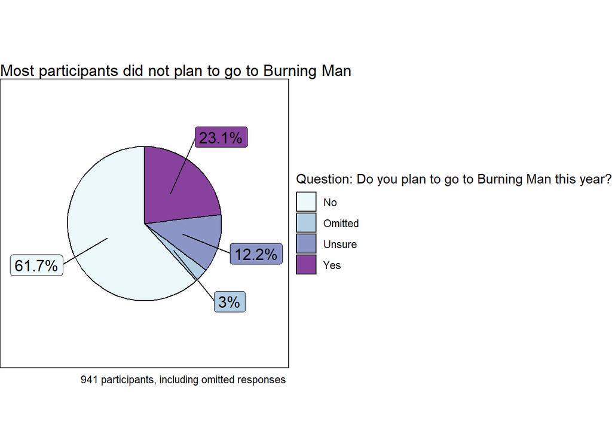

Do you plan to attend Burning Man this year?

| Response | 2023 Count | 2023 Percent | 2024 Count | 2024 Percent |
| --- | --- | --- | --- | --- |
| No | 401 | 59.9 | 581 | 61.7 |
| Omitted | 7 | 1.0 | 28 | 3.0 |
| Unsure | 114 | 17.0 | 115 | 12.2 |
| Yes | 148 | 22.1 | 217 | 23.1 |

The majority of participants (61.7%) did not plan to go to Burning Man in 2024, followed by 23.1% who planned to go. More people were decisive in 2024 than in 2023, with the unsure response dropping from 17% to 12.2%.

### Communication

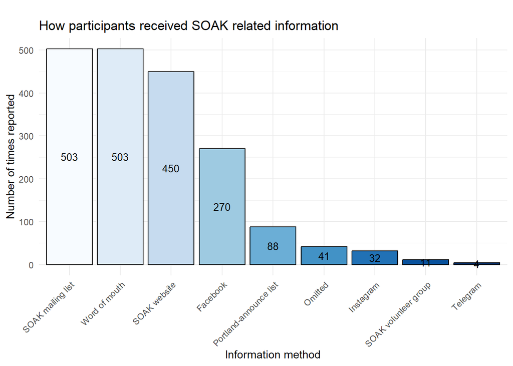

How did you receive SOAK related information?

| Information | 2023 Count | 2023 Percent | 2024 Count | 2024 Percent |
| --- | --- | --- | --- | --- |
| SOAK mailing list | 339 | 26.2 | 503 | 26.4 |
| Word of mouth | 330 | 25.5 | 503 | 26.4 |
| SOAK website | 310 | 24.0 | 450 | 23.7 |
| Facebook | 211 | 16.3 | 270 | 14.2 |
| Portland-announce list | 57 | 4.4 | 88 | 4.6 |
| Omitted | 24 | 1.9 | 41 | 2.2 |
| Instagram | 15 | 1.2 | 32 | 1.7 |
| SOAK volunteer group | NA | NA | 11 | 0.6 |
| Telegram | 6 | 0.5 | 4 | 0.2 |
| Twitter | 2 | 0.2 | NA | NA |

SOAK’s mailing list and word of mouth are how most folks receive SOAK information.